# Jazz Revenue Forecasting: A Comparative Time Series Analysis

Shah Rukh Khan

2026-08-12

# 1 Executive Summary

This project forecasts Jazz Pakistan’s quarterly revenue for 2025 using five time-series models implemented in R: **AR, MA, ARMA, ARIMA and SARIMA**. The analysis uses 20 quarterly observations from 2020 Q1 to 2024 Q4. Each model is applied independently, four quarterly forecasts are generated for 2025, and the resulting forecasts are compared.

**Unit:** Revenue is reported in PKR million.

# 2 1. Data and Time Series

The dataset contains quarterly revenue observations from 2020 Q1 to 2024 Q4. The series is configured with a quarterly frequency of 4.

```r
library(readxl)
library(forecast)
library(tseries)
library(ggplot2)
library(dplyr)





data <- read_excel(file.choose())

View(data)





names(data)
```

```
##  [1] "Year"
##  [2] "Quarter"
##  [3] "Total Revenue (PKR mn)"
##  [4] "Service Revenue (PKR mn)"
##  [5] "EBITDA (PKR mn)"
##  [6] "EBIT / Operating Profit (PKR mn)"
##  [7] "Capex (PKR mn)"
##  [8] "Data Revenue (PKR mn)"
##  [9] "Customers (mn)"
## [10] "ARPU (PKR)"
## [11] "Data Usage (GB/user)"
## [12] "4G Penetration (%)"
## [13] "Operating Cost Proxy (Revenue - EBITDA)"
## [14] "Period"
```

```r
revenue <- data$`Total Revenue (PKR mn)`

revenue
```

```
##  [1] 49282 47054 50678 52266 55050 57164 57274 59439 60060 63528 64150 73883
## [13] 69700 77600 81538 84745 89700 96500 99900 98847
```

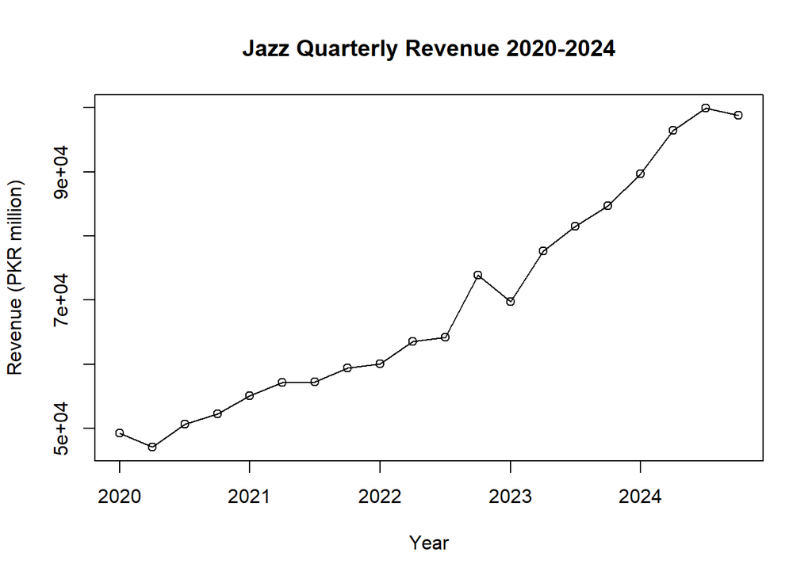

```r
revenue_ts <- ts(
  revenue,
  start = c(2020, 1),
  frequency = 4
)





plot(
  revenue_ts,
  type = "o",
  main = "Jazz Quarterly Revenue 2020-2024",
  xlab = "Year",
  ylab = "Revenue (PKR million)"
)
```

```r
revenue_ts
```

```
##       Qtr1  Qtr2  Qtr3  Qtr4
## 2020 49282 47054 50678 52266
## 2021 55050 57164 57274 59439
## 2022 60060 63528 64150 73883
## 2023 69700 77600 81538 84745
## 2024 89700 96500 99900 98847
```

```r
adf.test(revenue_ts)
```

```
##
##  Augmented Dickey-Fuller Test
##
## data:  revenue_ts
## Dickey-Fuller = -0.73608, Lag order = 2, p-value = 0.9553
## alternative hypothesis: stationary
```

```r
revenue_diff <- diff(revenue_ts)

revenue_diff
```

```
##       Qtr1  Qtr2  Qtr3  Qtr4
## 2020       -2228  3624  1588
## 2021  2784  2114   110  2165
## 2022   621  3468   622  9733
## 2023 -4183  7900  3938  3207
## 2024  4955  6800  3400 -1053
```

```r
adf.test(revenue_diff)
```

```
##
##  Augmented Dickey-Fuller Test
##
## data:  revenue_diff
## Dickey-Fuller = -2.7069, Lag order = 2, p-value = 0.3031
## alternative hypothesis: stationary
```

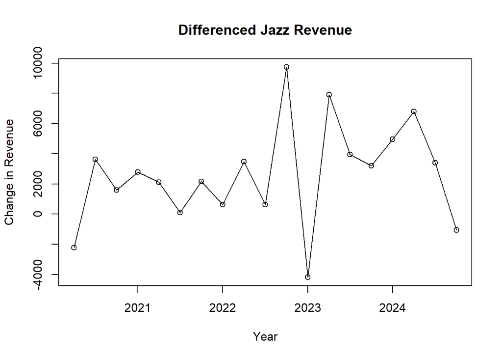

```r
plot(
  revenue_diff,
  type = "o",
  main = "Differenced Jazz Revenue",
  xlab = "Year",
  ylab = "Change in Revenue"
)
```

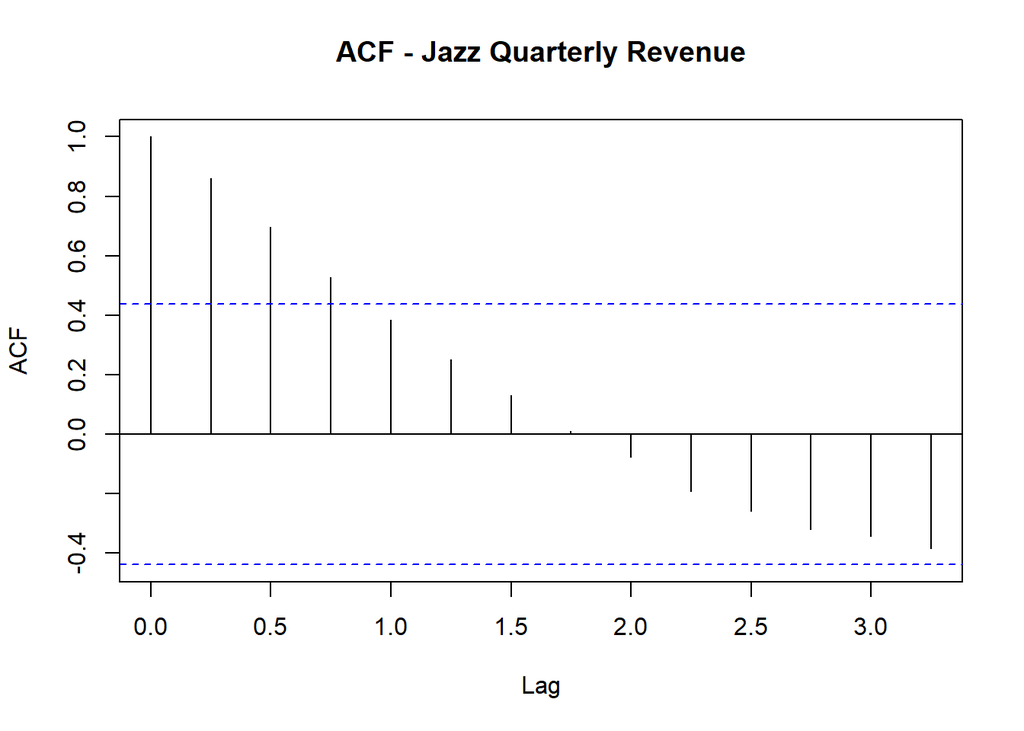

```r
acf(
  revenue_ts,
  main = "ACF - Jazz Quarterly Revenue"
)
```

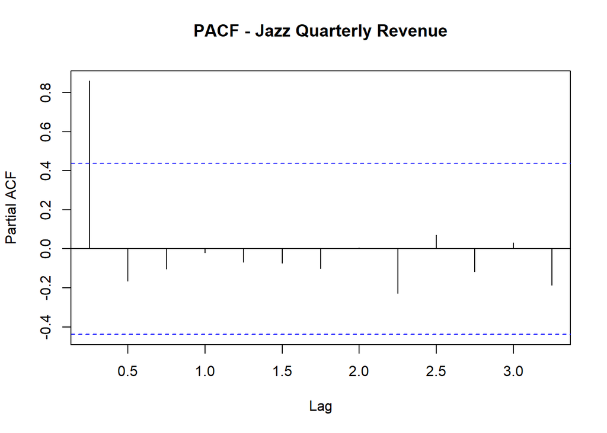

```r
pacf(
  revenue_ts,
  main = "PACF - Jazz Quarterly Revenue"
)
```

# 3 2. AR Model

The Autoregressive (AR) model uses previous observations of the series to model and forecast future revenue. The specified model is AR(1).

```r
ar_model <- Arima(
  revenue_ts,
  order = c(1, 0, 0)
)

summary(ar_model)
```

```
## Series: revenue_ts
## ARIMA(1,0,0) with non-zero mean
##
## Coefficients:
##          ar1      mean
##       0.9835  73441.80
## s.e.  0.0222  21508.25
##
## sigma^2 = 19461892:  log likelihood = -196.87
## AIC=399.75   AICc=401.25   BIC=402.74
##
## Training set error measures:
##                    ME     RMSE      MAE      MPE     MAPE      MASE       ACF1
## Training set 2172.255 4185.177 3367.193 2.664324 4.798854 0.2901705 -0.1497579
```

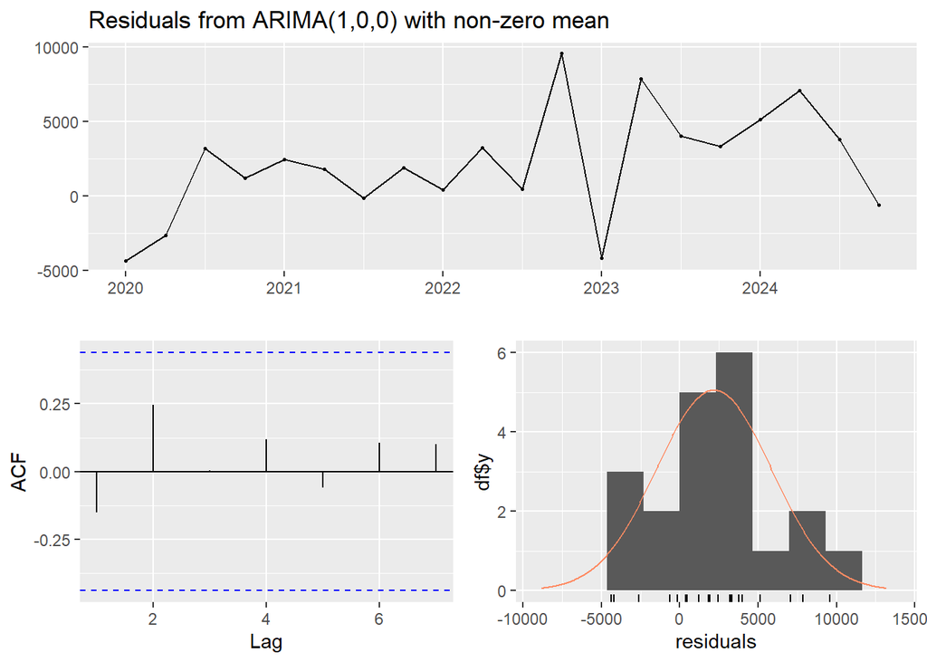

```
##
##  Ljung-Box test
##
## data:  Residuals from ARIMA(1,0,0) with non-zero mean
## Q* = 2.3947, df = 3, p-value = 0.4946
##
## Model df: 1.   Total lags used: 4
```

```r
checkresiduals(ar_model)
```

```r
ar_forecast <- forecast(
  ar_model,
  h = 4
)

ar_forecast
```

```
##         Point Forecast    Lo 80    Hi 80    Lo 95    Hi 95
## 2025 Q1       98427.59 92773.94 104081.2 89781.08 107074.1
## 2025 Q2       98015.10 90085.36 105944.8 85887.61 110142.6
## 2025 Q3       97609.42 87976.90 107241.9 82877.75 112341.1
## 2025 Q4       97210.44 86178.17 108242.7 80338.05 114082.8
```

```r
ar_2025 <- as.numeric(ar_forecast$mean)

ar_2025
```

```
## [1] 98427.59 98015.10 97609.42 97210.44
```

```r
ar_2025_table <- data.frame(
  Quarter = c(
    "Q1 2025",
    "Q2 2025",
    "Q3 2025",
    "Q4 2025"
  ),

  Forecast_Revenue_PKR_million = round(
    ar_2025,
    2
  )
)

ar_2025_table
```

| Quarter | Forecast_Revenue_PKR_million |
| --- | --- |
| Q1 2025 | 98427.59 |
| Q2 2025 | 98015.10 |
| Q3 2025 | 97609.42 |
| Q4 2025 | 97210.44 |

# 4 3. MA Model

The Moving Average (MA) model uses previous forecast errors to model and forecast future revenue. The specified model is MA(1).

```r
ma_model <- Arima(
  revenue_ts,
  order = c(0, 0, 1)
)

summary(ma_model)
```

```
## Series: revenue_ts
## ARIMA(0,0,1) with non-zero mean
##
## Coefficients:
##          ma1       mean
##       0.7888  69694.455
## s.e.  0.1119   4145.066
##
## sigma^2 = 124552514:  log likelihood = -214.21
## AIC=434.43   AICc=435.93   BIC=437.42
##
## Training set error measures:
##                    ME    RMSE      MAE       MPE     MAPE      MASE      ACF1
## Training set 295.2316 10587.6 9380.374 -3.014046 13.80964 0.8083611 0.6204673
```

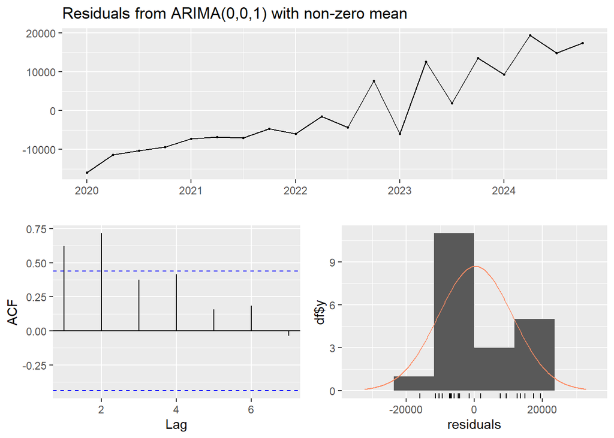

```
##
##  Ljung-Box test
##
## data:  Residuals from ARIMA(0,0,1) with non-zero mean
## Q* = 29.749, df = 3, p-value = 1.558e-06
##
## Model df: 1.   Total lags used: 4
```

```r
checkresiduals(ma_model)
```

```r
ma_forecast <- forecast(
  ma_model,
  h = 4
)

ma_forecast
```

```
##         Point Forecast    Lo 80    Hi 80    Lo 95     Hi 95
## 2025 Q1       83449.19 69146.55 97751.83 61575.19 105323.19
## 2025 Q2       69694.45 51477.79 87911.12 41834.46  97554.45
## 2025 Q3       69694.45 51477.79 87911.12 41834.46  97554.45
## 2025 Q4       69694.45 51477.79 87911.12 41834.46  97554.45
```

```r
ma_2025 <- as.numeric(
  ma_forecast$mean
)

ma_2025
```

```
## [1] 83449.19 69694.45 69694.45 69694.45
```

```r
ma_2025_table <- data.frame(
  Quarter = c(
    "Q1 2025",
    "Q2 2025",
    "Q3 2025",
    "Q4 2025"
  ),

  Forecast_Revenue_PKR_million = round(
    ma_2025,
    2
  )
)

ma_2025_table
```

| Quarter | Forecast_Revenue_PKR_million |
| --- | --- |
| Q1 2025 | 83449.19 |
| Q2 2025 | 69694.45 |
| Q3 2025 | 69694.45 |
| Q4 2025 | 69694.45 |

```r
ma_2025_total <- sum(
  ma_2025
)

round(
  ma_2025_total,
  2
)
```

```
## [1] 292532.5
```

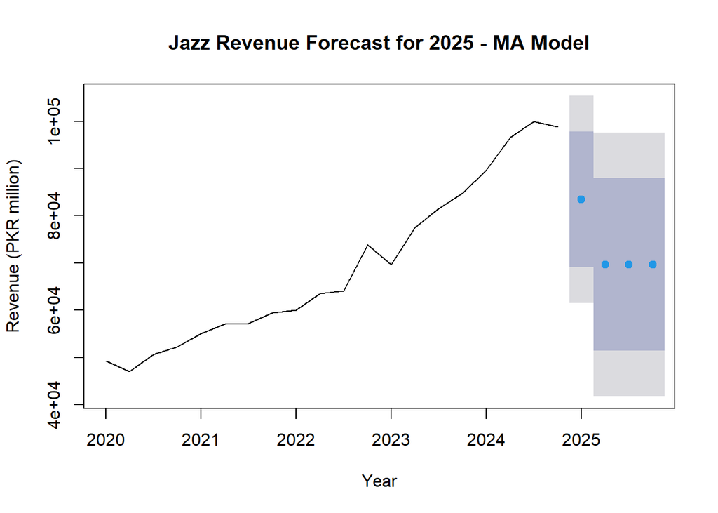

```r
plot(
  ma_forecast,
  main = "Jazz Revenue Forecast for 2025 - MA Model",
  xlab = "Year",
  ylab = "Revenue (PKR million)"
)
```

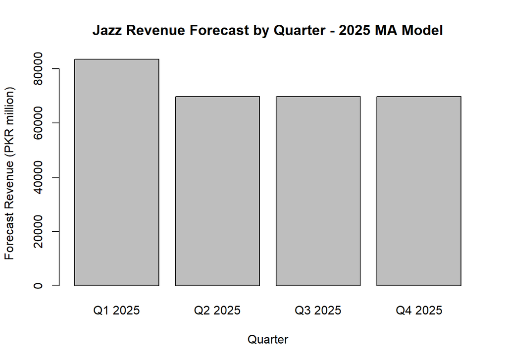

```r
barplot(
  ma_2025,
  names.arg = c(
    "Q1 2025",
    "Q2 2025",
    "Q3 2025",
    "Q4 2025"
  ),
  main = "Jazz Revenue Forecast by Quarter - 2025 MA Model",
  xlab = "Quarter",
  ylab = "Forecast Revenue (PKR million)"
)
```

```r
ma_forecast$lower
```

```
##              80%      95%
## 2025 Q1 69146.55 61575.19
## 2025 Q2 51477.79 41834.46
## 2025 Q3 51477.79 41834.46
## 2025 Q4 51477.79 41834.46
```

```r
ma_forecast$upper
```

```
##              80%       95%
## 2025 Q1 97751.83 105323.19
## 2025 Q2 87911.12  97554.45
## 2025 Q3 87911.12  97554.45
## 2025 Q4 87911.12  97554.45
```

```r
ma_final_results <- data.frame(
  Quarter = c(
    "Q1 2025",
    "Q2 2025",
    "Q3 2025",
    "Q4 2025",
    "TOTAL 2025"
  ),

  Forecast_Revenue_PKR_million = c(
    ma_2025,
    ma_2025_total
  )
)

ma_final_results
```

| Quarter | Forecast_Revenue_PKR_million |
| --- | --- |
| Q1 2025 | 83449.19 |
| Q2 2025 | 69694.45 |
| Q3 2025 | 69694.45 |
| Q4 2025 | 69694.45 |
| TOTAL 2025 | 292532.55 |

# 5 4. ARMA Model

The ARMA model combines autoregressive and moving-average components. The specified model is ARMA(1,1).

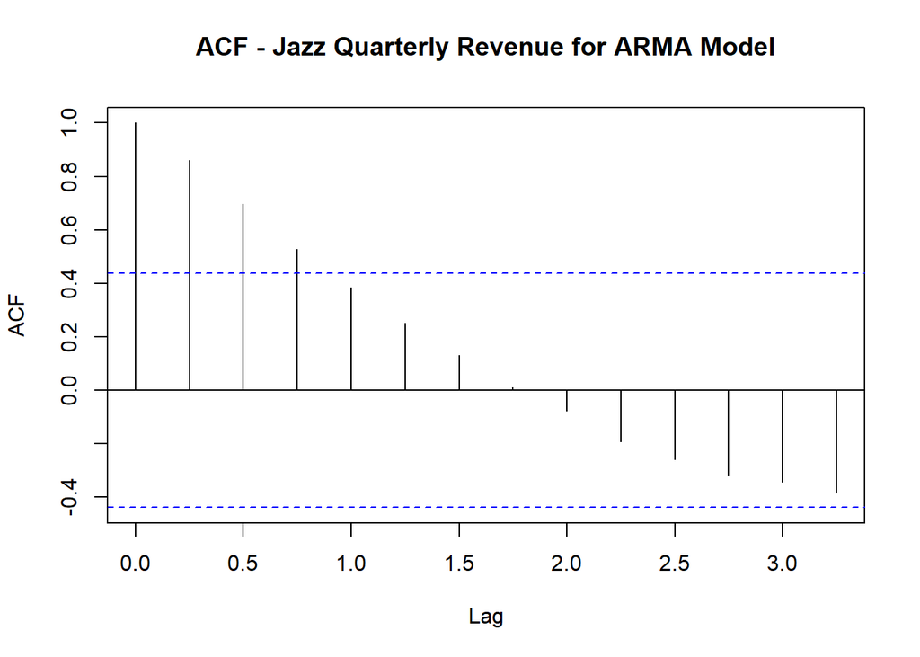

```r
acf(
  revenue_ts,
  main = "ACF - Jazz Quarterly Revenue for ARMA Model"
)
```

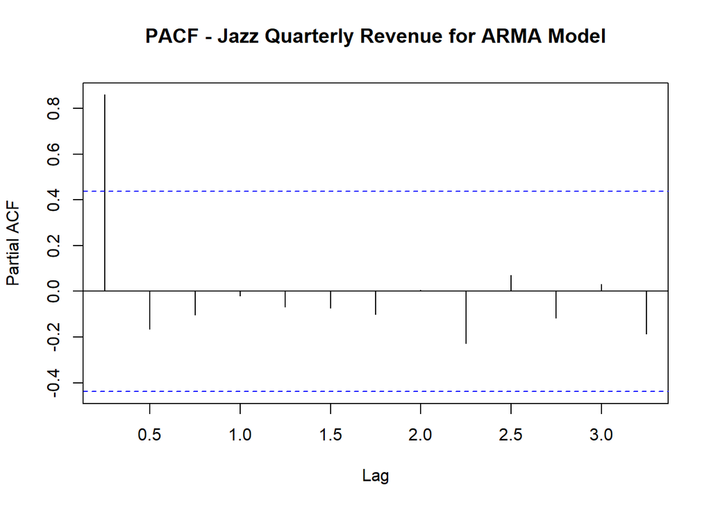

```r
pacf(
  revenue_ts,
  main = "PACF - Jazz Quarterly Revenue for ARMA Model"
)
```

```r
arma_model <- Arima(
  revenue_ts,
  order = c(1, 0, 1)
)

summary(arma_model)
```

```
## Series: revenue_ts
## ARIMA(1,0,1) with non-zero mean
##
## Coefficients:
```

```
##          ar1     ma1      mean
##       0.9975  0.1653  455936.8
## s.e.  0.0012  0.1996       NaN
##
## sigma^2 = 51768687:  log likelihood = -207.2
## AIC=422.39   AICc=425.06   BIC=426.38
##
## Training set error measures:
##                    ME     RMSE      MAE        MPE     MAPE      MASE
## Training set 107.9419 6633.505 3980.917 -0.8297371 6.353696 0.3430587
##                     ACF1
## Training set -0.01619977
```

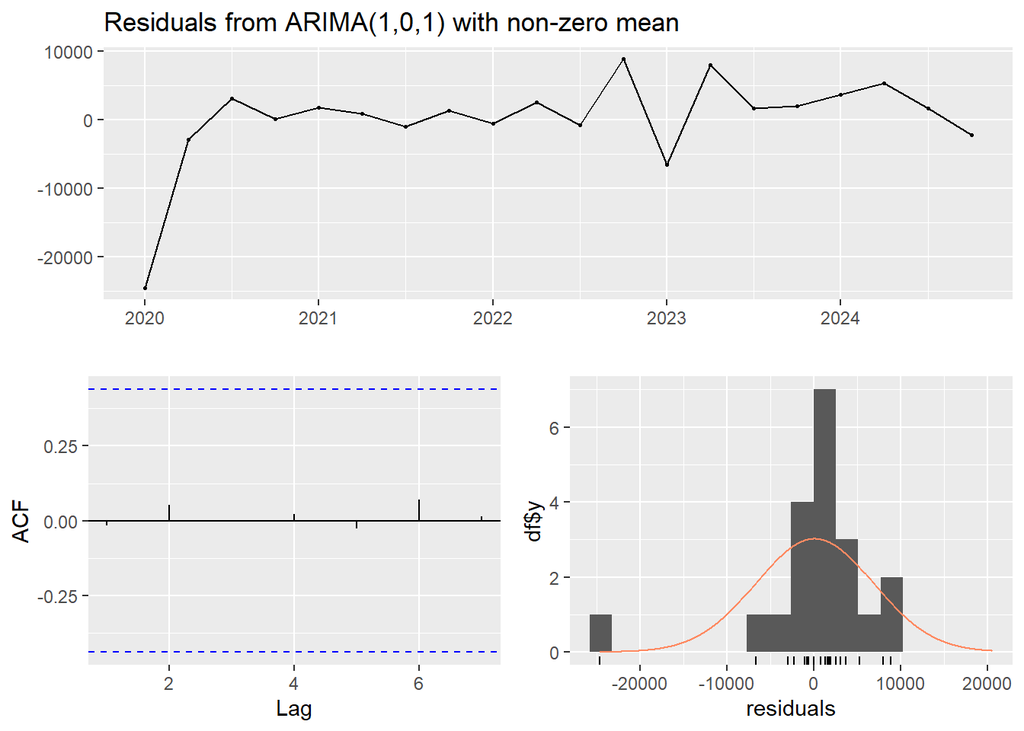

```
##
##  Ljung-Box test
##
## data:  Residuals from ARIMA(1,0,1) with non-zero mean
## Q* = 0.10671, df = 3, p-value = 0.991
##
## Model df: 2.   Total lags used: 5
```

```r
checkresiduals(arma_model)
```

```r
arma_forecast <- forecast(
  arma_model,
  h = 4
)

arma_forecast
```

```
##         Point Forecast    Lo 80    Hi 80    Lo 95    Hi 95
## 2025 Q1       99369.02 90148.20 108589.8 85266.99 113471.1
## 2025 Q2      100254.57 86113.08 114396.1 78627.03 121882.1
## 2025 Q3      101137.92 83407.45 118868.4 74021.51 128254.3
## 2025 Q4      102019.08 81326.33 122711.8 70372.25 133665.9
```

```r
arma_2025 <- as.numeric(
  arma_forecast$mean
)

arma_2025
```

```
## [1]  99369.02 100254.57 101137.92 102019.08
```

```r
arma_2025_table <- data.frame(
  Quarter = c(
    "Q1 2025",
    "Q2 2025",
    "Q3 2025",
    "Q4 2025"
  ),

  Forecast_Revenue_PKR_million = round(
    arma_2025,
    2
  )
)

arma_2025_table
```

| Quarter | Forecast_Revenue_PKR_million |
| --- | --- |
| Q1 2025 | 99369.02 |
| Q2 2025 | 100254.57 |
| Q3 2025 | 101137.92 |
| Q4 2025 | 102019.08 |

```r
arma_2025_total <- sum(
  arma_2025
)

round(
  arma_2025_total,
  2
)
```

```
## [1] 402780.6
```

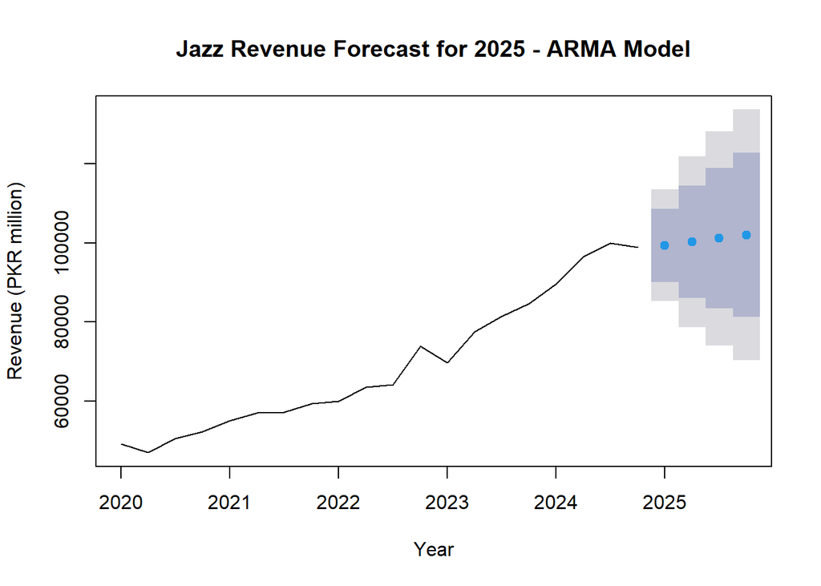

```r
plot(
  arma_forecast,
  main = "Jazz Revenue Forecast for 2025 - ARMA Model",
  xlab = "Year",
  ylab = "Revenue (PKR million)"
)
```

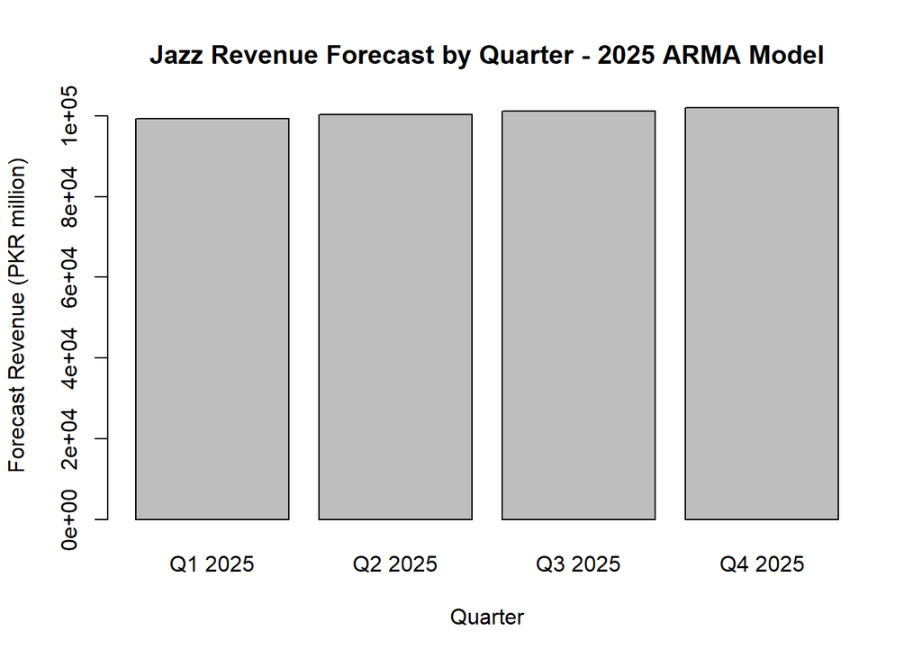

```r
barplot(
  arma_2025,
  names.arg = c(
    "Q1 2025",
    "Q2 2025",
    "Q3 2025",
    "Q4 2025"
  ),
  main = "Jazz Revenue Forecast by Quarter - 2025 ARMA Model",
  xlab = "Quarter",
  ylab = "Forecast Revenue (PKR million)"
)
```

```r
arma_forecast$lower
```

```
##              80%      95%
## 2025 Q1 90148.20 85266.99
## 2025 Q2 86113.08 78627.03
## 2025 Q3 83407.45 74021.51
## 2025 Q4 81326.33 70372.25
```

```r
arma_forecast$upper
```

```
##              80%      95%
## 2025 Q1 108589.8 113471.1
## 2025 Q2 114396.1 121882.1
## 2025 Q3 118868.4 128254.3
## 2025 Q4 122711.8 133665.9
```

```r
arma_final_results <- data.frame(
  Quarter = c(
    "Q1 2025",
    "Q2 2025",
    "Q3 2025",
    "Q4 2025",
    "TOTAL 2025"
  ),

  Forecast_Revenue_PKR_million = c(
    arma_2025,
    arma_2025_total
  )
)

arma_final_results
```

| Quarter | Forecast_Revenue_PKR_million |
| --- | --- |
| Q1 2025 | 99369.02 |
| Q2 2025 | 100254.57 |
| Q3 2025 | 101137.92 |
| Q4 2025 | 102019.08 |
| TOTAL 2025 | 402780.59 |

# 6 5. ARIMA Model

The ARIMA model adds differencing to the ARMA framework to address non-stationarity. The specified model is ARIMA(1,1,1).

```r
revenue_diff <- diff(revenue_ts)
revenue_diff
```

```
##       Qtr1  Qtr2  Qtr3  Qtr4
## 2020       -2228  3624  1588
## 2021  2784  2114   110  2165
## 2022   621  3468   622  9733
## 2023 -4183  7900  3938  3207
## 2024  4955  6800  3400 -1053
```

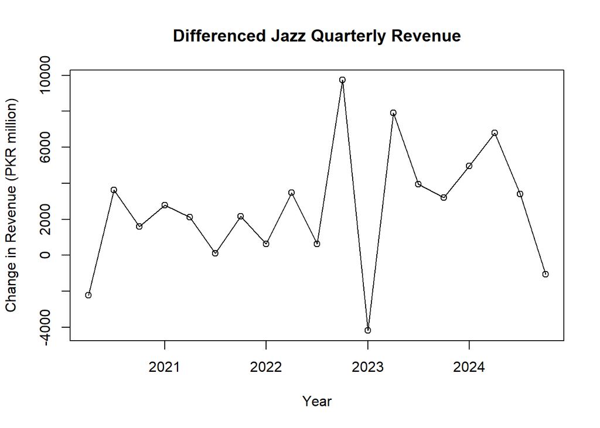

```r
plot(
  revenue_diff,
  type = "o",
  main = "Differenced Jazz Quarterly Revenue",
  xlab = "Year",
  ylab = "Change in Revenue (PKR million)"
)
```

```r
adf.test(revenue_diff)
```

```
##
##  Augmented Dickey-Fuller Test
##
## data:  revenue_diff
## Dickey-Fuller = -2.7069, Lag order = 2, p-value = 0.3031
## alternative hypothesis: stationary
```

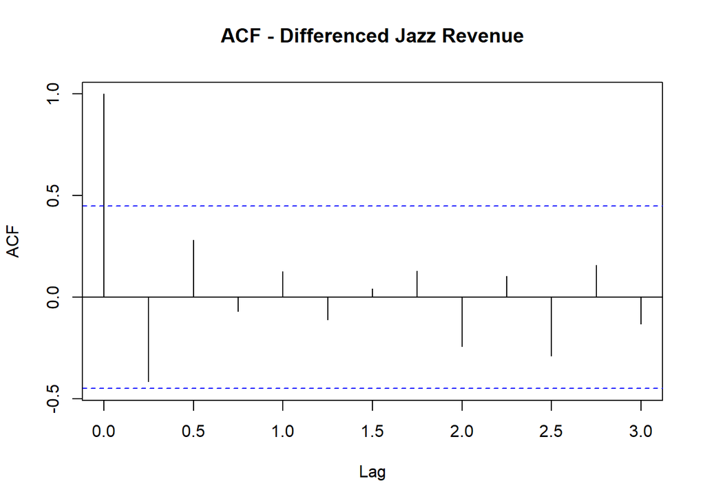

```r
acf(
  revenue_diff,
  main = "ACF - Differenced Jazz Revenue"
)
```

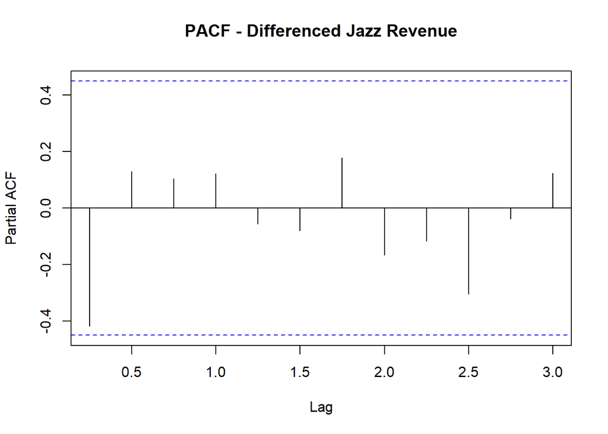

```r
pacf(
  revenue_diff,
  main = "PACF - Differenced Jazz Revenue"
)
```

```r
arima_model <- Arima(
  revenue_ts,
  order = c(1, 1, 1)
)

summary(arima_model)
```

```
## Series: revenue_ts
## ARIMA(1,1,1)
##
## Coefficients:
##          ar1      ma1
##       0.9918  -0.9087
## s.e.  0.0417   0.2211
##
## sigma^2 = 13528077:  log likelihood = -182.5
## AIC=371.01   AICc=372.61   BIC=373.84
##
## Training set error measures:
##                    ME     RMSE      MAE      MPE     MAPE      MASE       ACF1
## Training set 1124.201 3390.998 2553.351 1.574807 3.639979 0.2200371 -0.5152697
```

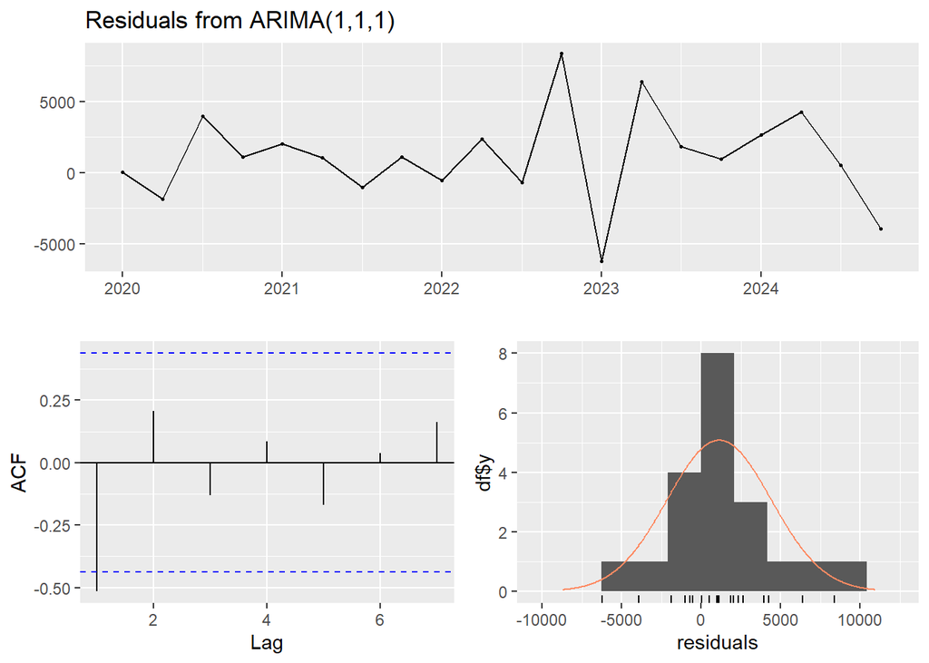

```
##
##  Ljung-Box test
##
## data:  Residuals from ARIMA(1,1,1)
## Q* = 8.6684, df = 3, p-value = 0.03404
##
## Model df: 2.   Total lags used: 5
```

```r
checkresiduals(arima_model)
```

```r
arima_forecast <- forecast(
  arima_model,
  h = 4
)

arima_forecast
```

```
##         Point Forecast    Lo 80    Hi 80    Lo 95    Hi 95
## 2025 Q1       101377.7 96656.29 106099.1 94156.93 108598.5
## 2025 Q2       103887.8 96917.93 110857.6 93228.31 114547.2
## 2025 Q3       106377.4 97481.88 115272.9 92772.88 119981.9
## 2025 Q4       108846.7 98159.92 119533.5 92502.67 125190.8
```

```r
arima_2025 <- as.numeric(
  arima_forecast$mean
)

arima_2025
```

```
## [1] 101377.7 103887.8 106377.4 108846.7
```

```r
arima_2025_table <- data.frame(
  Quarter = c(
    "Q1 2025",
    "Q2 2025",
    "Q3 2025",
    "Q4 2025"
  ),

  Forecast_Revenue_PKR_million = round(
    arima_2025,
    2
  )
)

arima_2025_table
```

| Quarter | Forecast_Revenue_PKR_million |
| --- | --- |
| Q1 2025 | 101377.7 |
| Q2 2025 | 103887.8 |
| Q3 2025 | 106377.4 |
| Q4 2025 | 108846.7 |

```r
arima_2025_total <- sum(
  arima_2025
)

round(
  arima_2025_total,
  2
)
```

```
## [1] 420489.6
```

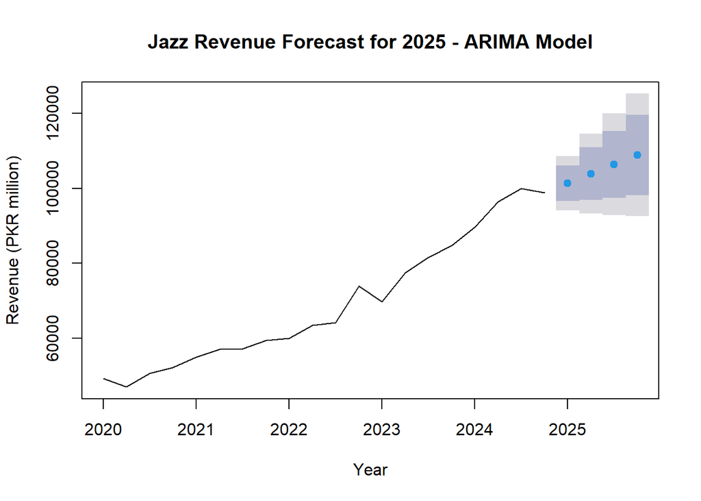

```r
plot(
  arima_forecast,
  main = "Jazz Revenue Forecast for 2025 - ARIMA Model",
  xlab = "Year",
  ylab = "Revenue (PKR million)"
)
```

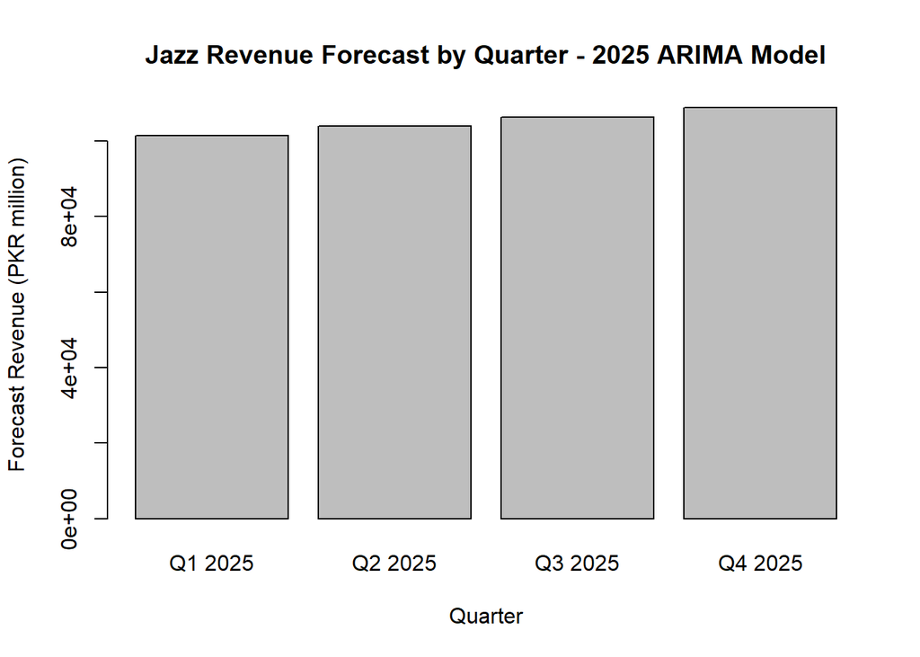

```r
barplot(
  arima_2025,
  names.arg = c(
    "Q1 2025",
    "Q2 2025",
    "Q3 2025",
    "Q4 2025"
  ),
  main = "Jazz Revenue Forecast by Quarter - 2025 ARIMA Model",
  xlab = "Quarter",
  ylab = "Forecast Revenue (PKR million)"
)
```

```r
arima_forecast$lower
```

```
##              80%      95%
## 2025 Q1 96656.29 94156.93
## 2025 Q2 96917.93 93228.31
## 2025 Q3 97481.88 92772.88
## 2025 Q4 98159.92 92502.67
```

```r
arima_forecast$upper
```

```
##              80%      95%
## 2025 Q1 106099.1 108598.5
## 2025 Q2 110857.6 114547.2
## 2025 Q3 115272.9 119981.9
## 2025 Q4 119533.5 125190.8
```

```r
arima_final_results <- data.frame(
  Quarter = c(
    "Q1 2025",
    "Q2 2025",
    "Q3 2025",
    "Q4 2025",
    "TOTAL 2025"
  ),

  Forecast_Revenue_PKR_million = c(
    arima_2025,
    arima_2025_total
  )
)

arima_final_results
```

| Quarter | Forecast_Revenue_PKR_million |
| --- | --- |
| Q1 2025 | 101377.7 |
| Q2 2025 | 103887.8 |
| Q3 2025 | 106377.4 |
| Q4 2025 | 108846.7 |
| TOTAL 2025 | 420489.6 |

# 7 6. SARIMA Model

The SARIMA model extends ARIMA by incorporating seasonal dynamics. Because the data are quarterly, the seasonal period is 4. The specified model is SARIMA(1,1,1)(1,1,1)[4].

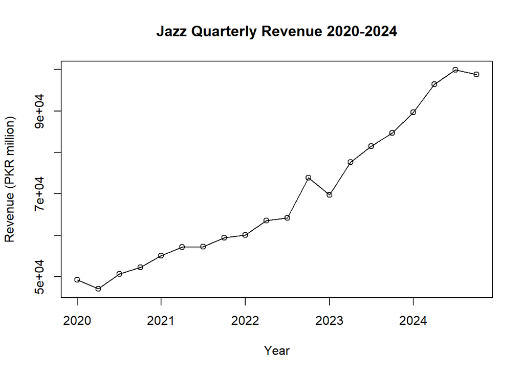

```r
plot(
  revenue_ts,
  type = "o",
  main = "Jazz Quarterly Revenue 2020-2024",
  xlab = "Year",
  ylab = "Revenue (PKR million)"
)
```

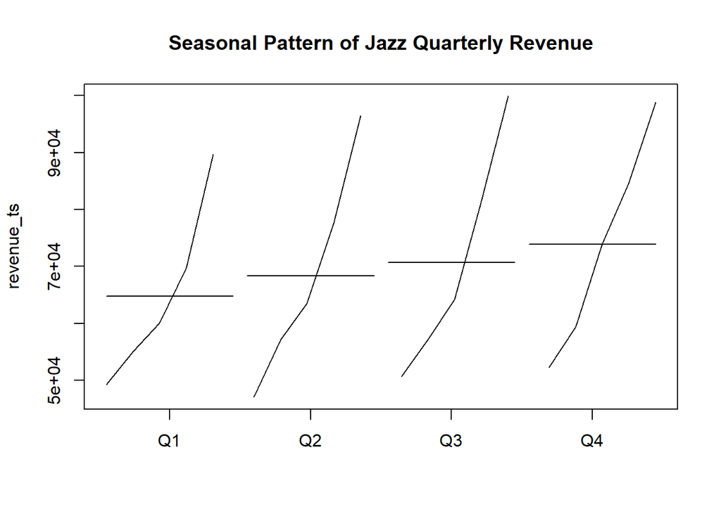

```r
monthplot(
  revenue_ts,
  main = "Seasonal Pattern of Jazz Quarterly Revenue"
)
```

```r
seasonal_diff <- diff(
  revenue_ts,
  lag = 4
)

seasonal_diff
```

```
##       Qtr1  Qtr2  Qtr3  Qtr4
## 2021  5768 10110  6596  7173
## 2022  5010  6364  6876 14444
## 2023  9640 14072 17388 10862
## 2024 20000 18900 18362 14102
```

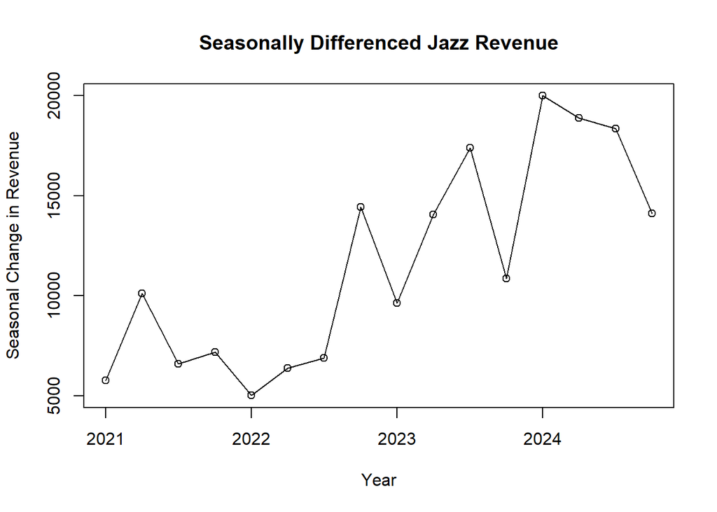

```r
plot(
  seasonal_diff,
  type = "o",
  main = "Seasonally Differenced Jazz Revenue",
  xlab = "Year",
  ylab = "Seasonal Change in Revenue"
)
```

```r
adf.test(seasonal_diff)
```

```
##
##  Augmented Dickey-Fuller Test
##
## data:  seasonal_diff
## Dickey-Fuller = -2.3442, Lag order = 2, p-value = 0.4413
## alternative hypothesis: stationary
```

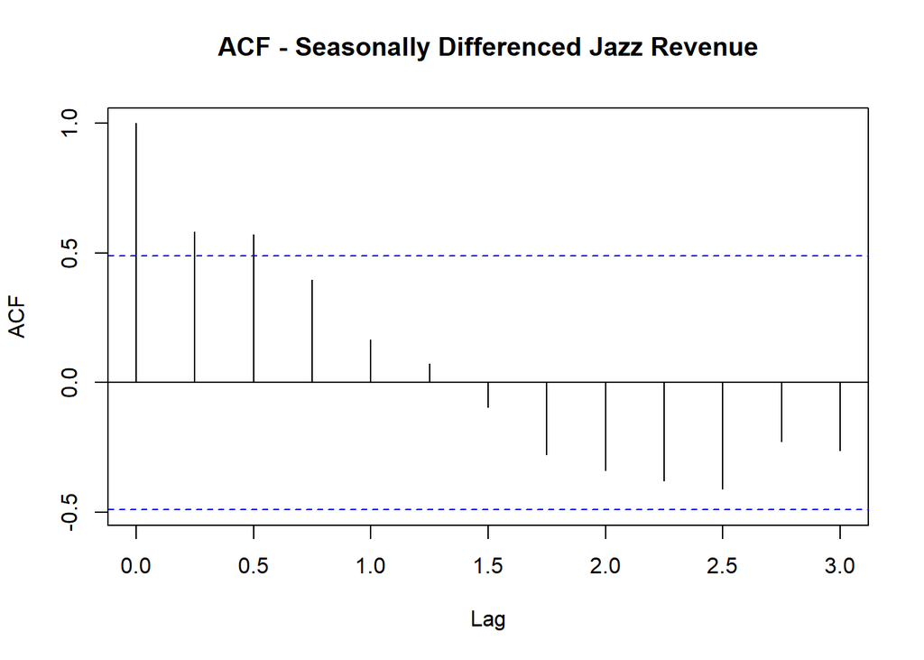

```r
acf(
  seasonal_diff,
  main = "ACF - Seasonally Differenced Jazz Revenue"
)
```

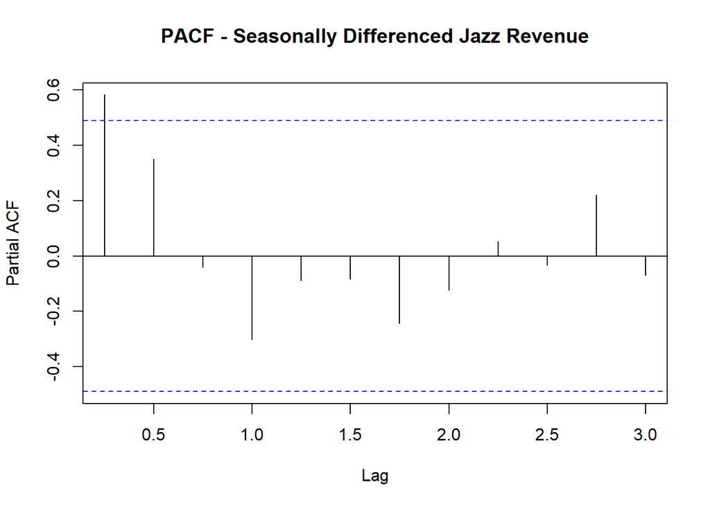

```r
pacf(
  seasonal_diff,
  main = "PACF - Seasonally Differenced Jazz Revenue"
)
```

```r
sarima_model <- Arima(
  revenue_ts,
  order = c(1, 1, 1),
  seasonal = c(1, 1, 1)
)

summary(sarima_model)
```

```
## Series: revenue_ts
## ARIMA(1,1,1)(1,1,1)[4]
##
## Coefficients:
##           ar1      ma1    sar1     sma1
##       -0.4493  -0.1080  0.6528  -0.9999
## s.e.   0.3970   0.4101  0.4308   0.7312
##
## sigma^2 = 15486376:  log likelihood = -144.44
## AIC=298.88   AICc=305.54   BIC=302.42
##
## Training set error measures:
##                    ME     RMSE     MAE      MPE     MAPE      MASE       ACF1
## Training set 871.0107 2918.477 2077.56 1.102206 2.708646 0.1790354 -0.1260125
```

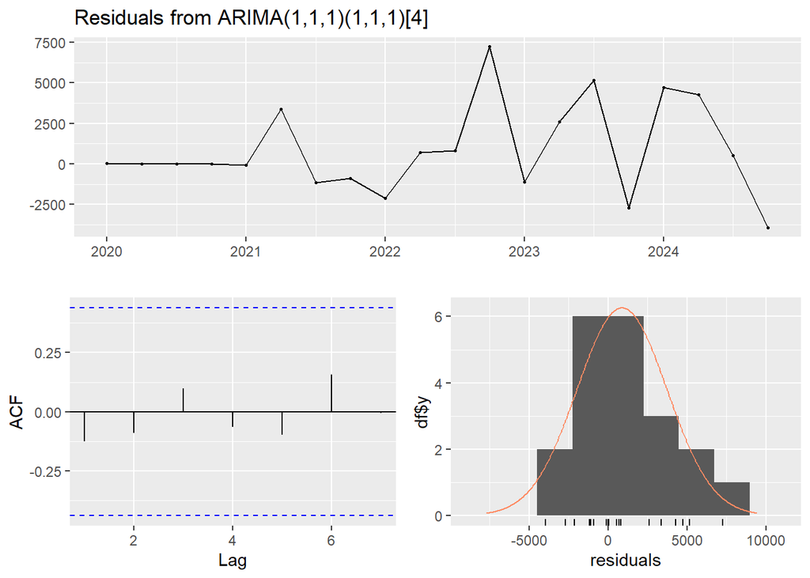

```
##
##  Ljung-Box test
##
## data:  Residuals from ARIMA(1,1,1)(1,1,1)[4]
## Q* = 1.9836, df = 3, p-value = 0.5758
##
## Model df: 4.   Total lags used: 7
```

```r
checkresiduals(sarima_model)
```

```r
sarima_forecast <- forecast(
  sarima_model,
  h = 4
)

sarima_forecast
```

```
##         Point Forecast    Lo 80    Hi 80     Lo 95    Hi 95
## 2025 Q1       105558.7 100208.9 110908.5  97376.95 113740.5
## 2025 Q2       110000.0 104154.6 115845.4 101060.27 118939.8
## 2025 Q3       113725.6 106812.2 120638.9 103152.50 124298.6
## 2025 Q4       113363.2 105794.5 120931.9 101787.87 124938.5
```

```r
sarima_2025 <- as.numeric(
  sarima_forecast$mean
)

sarima_2025
```

```
## [1] 105558.7 110000.0 113725.6 113363.2
```

```r
sarima_2025_table <- data.frame(
  Quarter = c(
    "Q1 2025",
    "Q2 2025",
    "Q3 2025",
    "Q4 2025"
  ),

  Forecast_Revenue_PKR_million = round(
    sarima_2025,
    2
  )
)

sarima_2025_table
```

| Quarter | Forecast_Revenue_PKR_million |
| --- | --- |
| Q1 2025 | 105558.7 |
| Q2 2025 | 110000.0 |
| Q3 2025 | 113725.6 |
| Q4 2025 | 113363.2 |

```r
sarima_2025_total <- sum(
  sarima_2025
)

round(
  sarima_2025_total,
  2
)
```

```
## [1] 442647.5
```

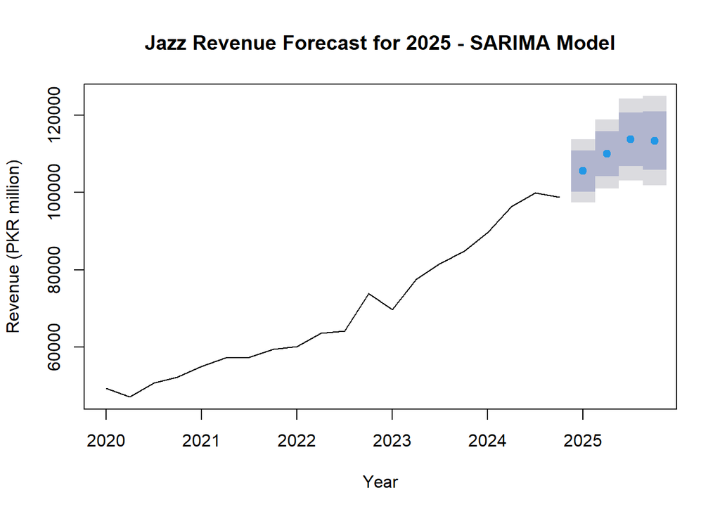

```r
plot(
  sarima_forecast,
  main = "Jazz Revenue Forecast for 2025 - SARIMA Model",
  xlab = "Year",
  ylab = "Revenue (PKR million)"
)
```

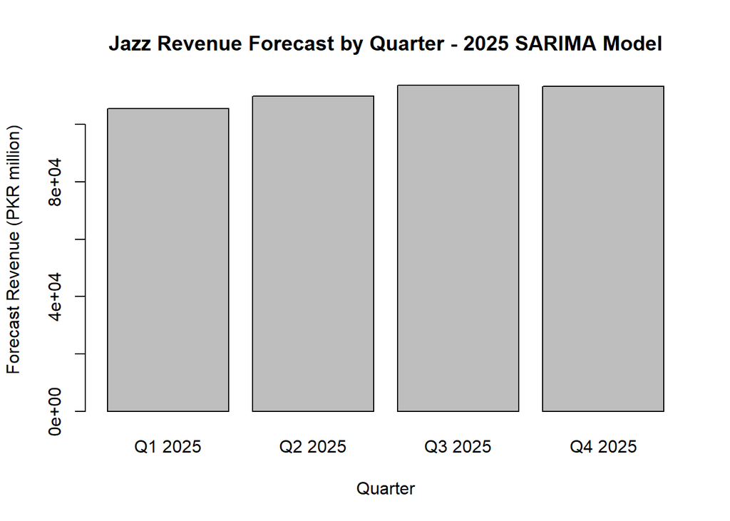

```r
barplot(
  sarima_2025,
  names.arg = c(
    "Q1 2025",
    "Q2 2025",
    "Q3 2025",
    "Q4 2025"
  ),
  main = "Jazz Revenue Forecast by Quarter - 2025 SARIMA Model",
  xlab = "Quarter",
  ylab = "Forecast Revenue (PKR million)"
)
```

```r
sarima_forecast$lower
```

```
##              80%       95%
## 2025 Q1 100208.9  97376.95
## 2025 Q2 104154.6 101060.27
## 2025 Q3 106812.2 103152.50
## 2025 Q4 105794.5 101787.87
```

```r
sarima_forecast$upper
```

```
##              80%      95%
## 2025 Q1 110908.5 113740.5
## 2025 Q2 115845.4 118939.8
## 2025 Q3 120638.9 124298.6
## 2025 Q4 120931.9 124938.5
```

```r
sarima_final_results <- data.frame(
  Quarter = c(
    "Q1 2025",
    "Q2 2025",
    "Q3 2025",
    "Q4 2025",
    "TOTAL 2025"
  ),

  Forecast_Revenue_PKR_million = c(
    sarima_2025,
    sarima_2025_total
  )
)

sarima_final_results
```

| Quarter | Forecast_Revenue_PKR_million |
| --- | --- |
| Q1 2025 | 105558.7 |
| Q2 2025 | 110000.0 |
| Q3 2025 | 113725.6 |
| Q4 2025 | 113363.2 |
| TOTAL 2025 | 442647.5 |

# 8 7. Final Comparison of the Five Models

## 8.1 7.1 Total Revenue Forecast for 2025

The total 2025 forecast is calculated by summing the four quarterly forecasts produced by each model.

```r
final_comparison <- data.frame(
  Model = c("AR", "MA", "ARMA", "ARIMA", "SARIMA"),
  Total_2025_Revenue_PKR_million = round(c(
    sum(ar_2025),
    sum(ma_2025),
    sum(arma_2025),
    sum(arima_2025),
    sum(sarima_2025)
  ), 2)
)

knitr::kable(
  final_comparison,
  caption = "Comparison of Total 2025 Revenue Forecasts"
)
```

Comparison of Total 2025 Revenue Forecasts

| Model | Total_2025_Revenue_PKR_million |
| --- | --- |
| AR | 391262.5 |
| MA | 292532.5 |
| ARMA | 402780.6 |
| ARIMA | 420489.6 |
| SARIMA | 442647.5 |

## 8.2 7.2 Quarterly Forecast Comparison

```r
quarterly_comparison <- data.frame(
  Quarter = c("Q1 2025", "Q2 2025", "Q3 2025", "Q4 2025"),
  AR = round(ar_2025, 2),
  MA = round(ma_2025, 2),
  ARMA = round(arma_2025, 2),
  ARIMA = round(arima_2025, 2),
  SARIMA = round(sarima_2025, 2)
)

knitr::kable(
  quarterly_comparison,
  caption = "Quarterly 2025 Revenue Forecast Comparison"
)
```

Quarterly 2025 Revenue Forecast Comparison

| Quarter | AR | MA | ARMA | ARIMA | SARIMA |
| --- | --- | --- | --- | --- | --- |
| Q1 2025 | 98427.59 | 83449.19 | 99369.02 | 101377.7 | 105558.7 |
| Q2 2025 | 98015.10 | 69694.45 | 100254.57 | 103887.8 | 110000.0 |
| Q3 2025 | 97609.42 | 69694.45 | 101137.92 | 106377.4 | 113725.6 |
| Q4 2025 | 97210.44 | 69694.45 | 102019.08 | 108846.7 | 113363.2 |

## 8.3 7.3 Total Forecast Comparison Graph

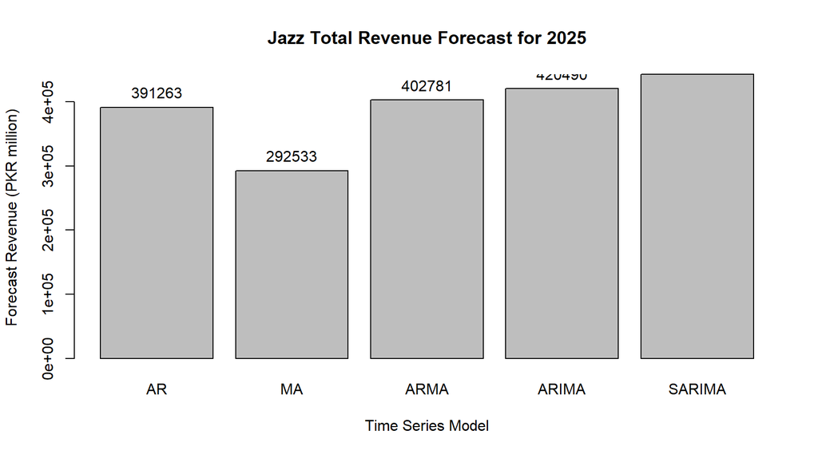

```r
bar_positions <- barplot(
  final_comparison$Total_2025_Revenue_PKR_million,
  names.arg = final_comparison$Model,
  main = "Jazz Total Revenue Forecast for 2025",
  xlab = "Time Series Model",
  ylab = "Forecast Revenue (PKR million)"
)

text(
  x = bar_positions,
  y = final_comparison$Total_2025_Revenue_PKR_million,
  labels = round(final_comparison$Total_2025_Revenue_PKR_million, 0),
  pos = 3
)
```

## 8.4 7.4 Quarterly Forecast Comparison Graph

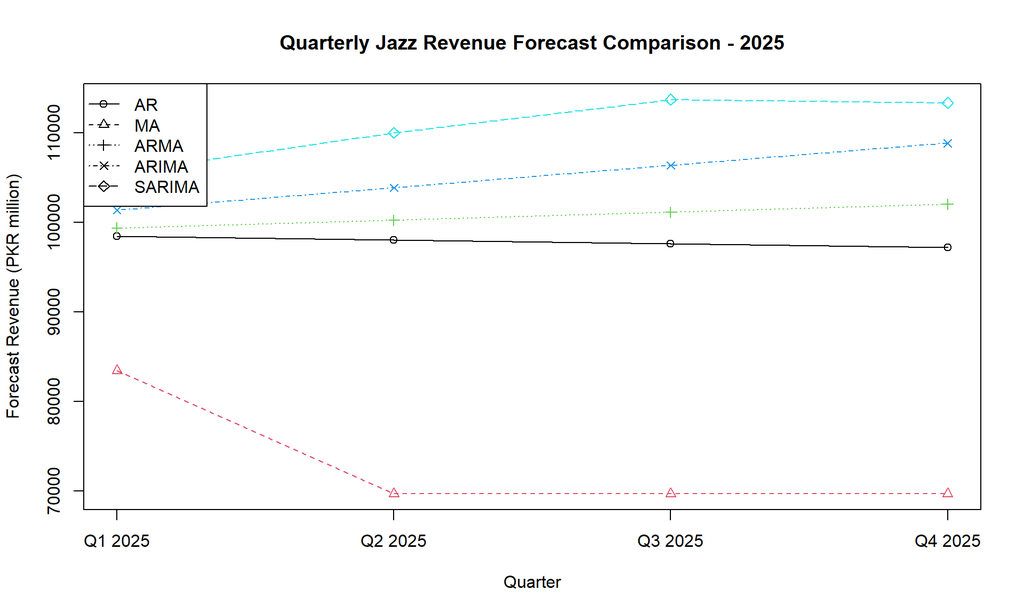

```r
comparison_matrix <- rbind(
  AR = ar_2025,
  MA = ma_2025,
  ARMA = arma_2025,
  ARIMA = arima_2025,
  SARIMA = sarima_2025
)

matplot(
  1:4,
  t(comparison_matrix),
  type = "o",
  pch = 1:5,
  lty = 1:5,
  xaxt = "n",
  xlab = "Quarter",
  ylab = "Forecast Revenue (PKR million)",
  main = "Quarterly Jazz Revenue Forecast Comparison - 2025"
)

axis(
  1,
  at = 1:4,
  labels = c("Q1 2025", "Q2 2025", "Q3 2025", "Q4 2025")
)

legend(
  "topleft",
  legend = rownames(comparison_matrix),
  pch = 1:5,
  lty = 1:5
)
```

# 9 8. Conclusion

This analysis applies five time-series forecasting approaches to Jazz quarterly revenue data from 2020 Q1 to 2024 Q4. Each model produces independent quarterly forecasts for 2025, and the four quarterly forecasts are aggregated to obtain an estimated total 2025 revenue.

The final comparison demonstrates how different model structures can lead to different revenue forecasts. Model selection should be informed by stationarity, residual diagnostics, model fit and forecasting performance rather than by the forecast value alone.